#### Statistics for Laboratory Scientists ( 140.615 )

## Principal Components Analysis

#### Example 1: father and daughter heights

Plot the data using identical axis.

```r
library(SPH.140.615)
par(pty="s")
r <- range(pear)
r
```

```
## [1] 52.6 76.0
```

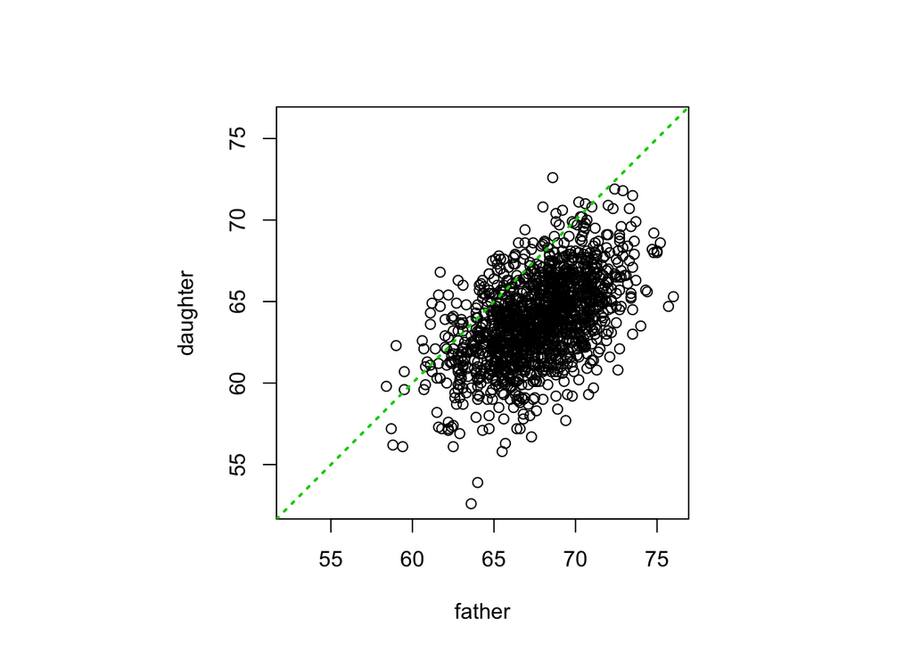

```r
plot(pear ,xlim=r, ylim=r)
abline(c(0,1), lty="dotted", col="green3", lwd=2)
```

Calculate the principal components, and add them to the scatter plot.

```r
pear.pca <- prcomp(pear, retx=TRUE, center=TRUE, scale.=TRUE)
int <- pear.pca$center
int
```

```
##   father daughter
## 67.67871 63.83823
```

```r
rot <- pear.pca$rotation
rot
```

```
##                PC1        PC2
## father   0.7071068 -0.7071068
## daughter 0.7071068  0.7071068
```

```r
b1 <- rot[2,1]/rot[1,1]
b1
```

```
## [1] 1
```

```r
a1 <- int[2]-b1*int[1]
a1
```

```
## daughter
## -3.84048
```

```r
b2 <- rot[2,2]/rot[1,2]
b2
```

```
## [1] -1
```

```r
a2 <- int[2]-b2*int[1]
a2
```

```
## daughter
## 131.5169
```

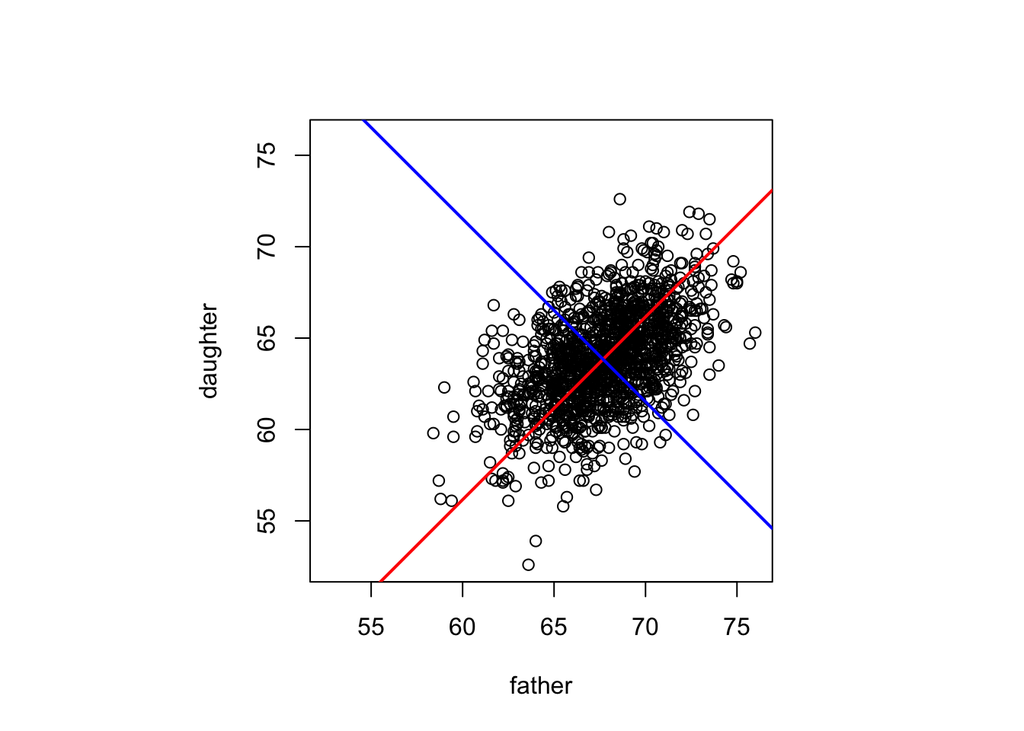

```r
par(pty="s")
plot(pear ,xlim=r, ylim=r)
abline(a1, b1, col="red", lwd=2)
abline(a2, b2, col="blue",lwd=2)
```

Plot the “principal components”, here, the rotated data.

```r
head(pear.pca$x)
```

```
##            PC1         PC2
## [1,] -4.032912 -1.95068591
## [2,] -3.584728 -1.70670702
## [3,] -2.696034 -1.58377961
## [4,] -4.299761  0.23291997
## [5,] -4.173229  0.05314493
## [6,] -3.381936 -0.73814768
```

```r
head(predict(pear.pca))
```

```
##            PC1         PC2
## [1,] -4.032912 -1.95068591
## [2,] -3.584728 -1.70670702
## [3,] -2.696034 -1.58377961
## [4,] -4.299761  0.23291997
## [5,] -4.173229  0.05314493
## [6,] -3.381936 -0.73814768
```

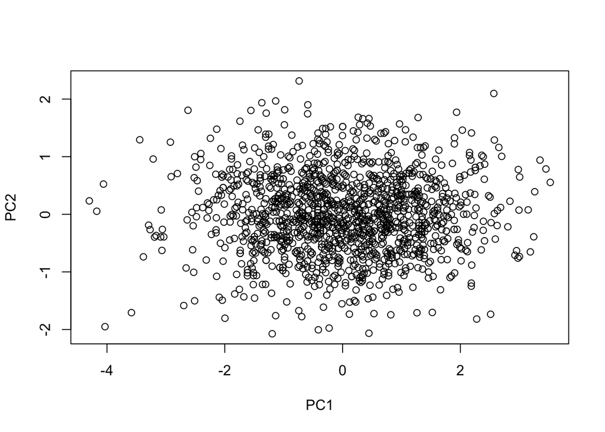

```r
par(pty="m")
plot(pear.pca$x)
```

The variance contributions.

```r
summary(pear.pca)
```

```
## Importance of components:
##                           PC1    PC2
## Standard deviation     1.2318 0.6947
## Proportion of Variance 0.7587 0.2413
## Cumulative Proportion  0.7587 1.0000
```

#### Example 2: Multivariate Normal distribution in 10 dimensions

A function to simulate multivariate normal data.

```r
myrmvn <- function(mu,sigma,hm=1,...){
  n=length(mu)
  if(sum((dim(sigma)-rep(n,2))^2)!=0)
    stop("Check the dimensions of mu and sigma!")
  if(det(sigma)==0) stop("The covariance matrix is singular!")
  a=t(chol(sigma))
  z=matrix(rnorm(n*hm),nrow=n)
  y=t(a%*%z+mu)
  return(y)
}
```

Generate a mean vector of zeros, and a variance-covariance matrix with some strong correlations.

```r
mu <- rep(0,10)
mu
```

```
##  [1] 0 0 0 0 0 0 0 0 0 0
```

```r
sigma <- diag(0.2,10)+0.8
sigma[1:8,9:10] <- 0.2
sigma[9:10,1:8] <- 0.2
sigma
```

```
##       [,1] [,2] [,3] [,4] [,5] [,6] [,7] [,8] [,9] [,10]
##  [1,]  1.0  0.8  0.8  0.8  0.8  0.8  0.8  0.8  0.2   0.2
##  [2,]  0.8  1.0  0.8  0.8  0.8  0.8  0.8  0.8  0.2   0.2
##  [3,]  0.8  0.8  1.0  0.8  0.8  0.8  0.8  0.8  0.2   0.2
##  [4,]  0.8  0.8  0.8  1.0  0.8  0.8  0.8  0.8  0.2   0.2
##  [5,]  0.8  0.8  0.8  0.8  1.0  0.8  0.8  0.8  0.2   0.2
##  [6,]  0.8  0.8  0.8  0.8  0.8  1.0  0.8  0.8  0.2   0.2
##  [7,]  0.8  0.8  0.8  0.8  0.8  0.8  1.0  0.8  0.2   0.2
##  [8,]  0.8  0.8  0.8  0.8  0.8  0.8  0.8  1.0  0.2   0.2
##  [9,]  0.2  0.2  0.2  0.2  0.2  0.2  0.2  0.2  1.0   0.8
## [10,]  0.2  0.2  0.2  0.2  0.2  0.2  0.2  0.2  0.8   1.0
```

Simulate data from a multivariate normal distribution with the mean vector and the variance-covariance matrix, and plot the data in the ten dimensions.

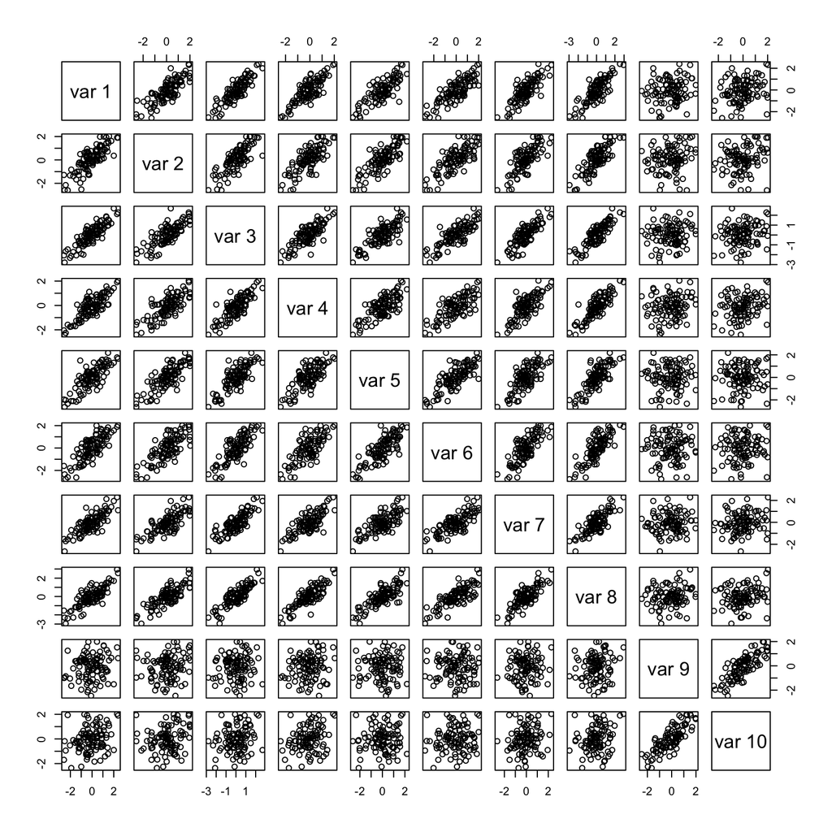

```r
set.seed(1)
n <- 100
dat <- myrmvn(mu,sigma,hm=n)
pairs(dat)
```

The principal components analysis.

```r
dat.pca <- prcomp(dat, retx=TRUE, center=TRUE, scale.=TRUE)
```

The variance contributions.

```r
summary(dat.pca)
```

```
## Importance of components:
##                           PC1    PC2    PC3     PC4     PC5    PC6     PC7     PC8     PC9    PC10
## Standard deviation     2.5745 1.3361 0.5604 0.50644 0.46858 0.4336 0.42375 0.40214 0.38626 0.34434
## Proportion of Variance 0.6628 0.1785 0.0314 0.02565 0.02196 0.0188 0.01796 0.01617 0.01492 0.01186
## Cumulative Proportion  0.6628 0.8413 0.8727 0.89834 0.92030 0.9391 0.95705 0.97322 0.98814 1.00000
```

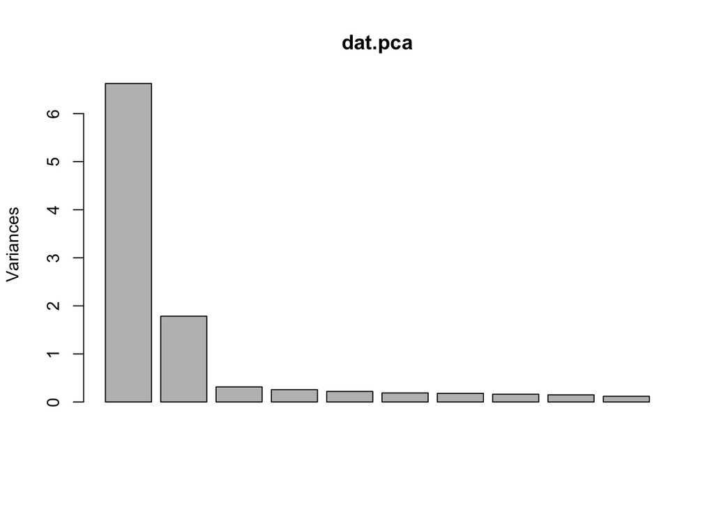

```r
plot(dat.pca)
```

#### Example 3: two populations with different genetic background

A function to simulate some single nucleotide polymorphisms (SNPs).

```r
my.snp.pc.data=function(n,maf){
  hm=length(maf)
  z=matrix(ncol=hm,nrow=n)
  for(j in 1:hm){
    p=1-maf[j]
    mp=c(p^2,2*p*(1-p),(1-p)^2)
    z[,j]=apply(rmultinom(n,1,mp),2,order)[3,]-1
  }
  return(z)
}
```

We have two populations, and we measure the genotype at 50 loci with differing minor allele frequencies (MAFs). These type of loci are often called ancestry informative markers.

Here are the minor allele frequencies for the 50 SNPs.

```r
ns <- 50
set.seed(1)
maf1 <- runif(ns,0.1,0.5)
maf2 <- runif(ns,0.1,0.5)
maf1
```

```
##  [1] 0.2062035 0.2488496 0.3291413 0.4632831 0.1806728 0.4593559 0.4778701 0.3643191 0.3516456 0.1247145
## [11] 0.1823898 0.1706227 0.3748091 0.2536415 0.4079366 0.2990797 0.3870474 0.4967624 0.2520141 0.4109781
## [21] 0.4738821 0.1848570 0.3606695 0.1502220 0.2068883 0.2544456 0.1053561 0.2529552 0.4478763 0.2361396
## [31] 0.2928320 0.3398263 0.2974165 0.1744870 0.4309493 0.3673867 0.4176959 0.1431775 0.3894844 0.2645098
## [41] 0.4283785 0.3588241 0.4131731 0.3212145 0.3118878 0.4157425 0.1093325 0.2908920 0.3929255 0.3770926
```

```r
maf2
```

```
##  [1] 0.2910478 0.4444838 0.2752388 0.1979189 0.1282716 0.1397865 0.2265087 0.3074537 0.3648020 0.2627321
## [11] 0.4651504 0.2174413 0.2836263 0.2329579 0.3603482 0.2032067 0.2914181 0.4065243 0.1336988 0.4501285
## [21] 0.2356292 0.4357761 0.2386734 0.2335100 0.2905405 0.4568793 0.4457358 0.2559958 0.4109283 0.4842472
## [31] 0.2738638 0.3850059 0.2599977 0.2301409 0.4028349 0.1810769 0.3844485 0.1486768 0.1981954 0.1573218
## [41] 0.1958518 0.1235738 0.3569153 0.4505077 0.4115659 0.4189235 0.2821098 0.2640336 0.4243481 0.3419733
```

Randomly sample 100 subjects from each population.

```r
n1 <- n2 <- 100
z1 <- my.snp.pc.data(n1,maf1)
z2 <- my.snp.pc.data(n2,maf2)
z <- data.frame(rbind(z1,z2))
head(z,10)
```

```
##    X1 X2 X3 X4 X5 X6 X7 X8 X9 X10 X11 X12 X13 X14 X15 X16 X17 X18 X19 X20 X21 X22 X23 X24 X25 X26 X27 X28 X29
## 1   1  0  0  2  0  0  0  1  2   0   0   0   0   0   0   1   2   1   0   1   1   0   0   0   1   0   0   1   2
## 2   0  0  0  0  1  0  2  0  1   0   0   0   2   0   1   0   2   1   0   0   2   1   1   0   0   0   0   0   1
## 3   1  0  1  0  1  2  1  1  1   1   0   0   0   1   1   0   1   1   1   1   1   0   1   2   0   1   1   1   2
## 4   0  2  1  0  2  1  0  0  1   0   0   1   1   1   1   0   1   1   0   2   1   0   2   0   0   0   0   1   0
## 5   0  0  0  0  1  1  2  0  0   0   1   1   0   1   0   0   1   0   0   0   2   1   0   0   1   0   1   0   0
## 6   0  0  1  1  0  1  0  1  1   0   0   0   2   0   1   0   2   0   1   1   0   0   0   0   0   1   0   0   1
## 7   1  0  1  1  0  2  1  2  1   0   1   0   1   1   1   1   2   2   0   0   0   0   2   1   0   1   0   0   1
## 8   1  0  0  1  0  2  1  0  1   0   0   1   0   2   1   0   1   2   0   0   1   0   0   0   1   0   0   0   1
## 9   0  0  0  1  0  0  0  0  0   0   0   0   0   0   0   0   0   1   1   1   2   1   2   0   2   0   0   0   1
## 10  0  0  1  1  1  2  2  1  1   0   0   0   1   1   1   0   1   1   1   0   0   0   0   0   0   0   0   0   1
##    X30 X31 X32 X33 X34 X35 X36 X37 X38 X39 X40 X41 X42 X43 X44 X45 X46 X47 X48 X49 X50
## 1    1   0   1   0   0   2   0   0   0   0   1   0   0   2   0   1   2   1   0   0   1
## 2    0   0   0   0   0   1   0   1   0   0   0   1   1   0   0   1   1   0   1   0   1
## 3    1   0   2   0   1   1   1   0   0   2   0   0   1   0   0   0   0   1   0   0   1
## 4    0   0   2   0   0   1   1   2   0   2   0   1   0   0   0   0   0   0   0   1   1
## 5    1   1   0   0   0   1   0   1   0   1   0   2   1   1   0   1   0   0   1   1   0
## 6    0   1   2   1   1   1   1   1   0   0   1   0   0   1   1   1   1   1   0   1   0
## 7    1   2   2   0   1   0   1   2   1   0   1   0   0   1   0   1   1   0   0   2   0
## 8    0   1   1   1   1   2   0   1   0   1   0   0   1   0   0   2   1   0   1   0   1
## 9    1   1   0   1   0   1   0   2   0   2   1   0   0   1   0   0   1   1   0   2   1
## 10   0   1   1   0   0   0   0   2   1   0   2   0   0   1   2   0   2   0   1   2   1
```

The principal components analysis.

```r
snp.pca <- prcomp(z, retx=TRUE, center=TRUE, scale.=TRUE)
```

The principal components.

```r
snp.p <- predict(snp.pca)
dim(snp.p)
```

```
## [1] 200  50
```

```r
head(snp.p[,1:5],10)
```

```
##             PC1        PC2         PC3        PC4        PC5
##  [1,] 0.3673817 -0.2734193  0.09206113  1.1476370 -0.8903395
##  [2,] 2.5758992 -1.3162147  0.18734551  0.2379644 -1.0162325
##  [3,] 1.5395234  1.2247341 -1.74680376 -2.6340989 -1.3447263
##  [4,] 1.4044452  2.2137645  0.57825878 -2.0429535 -1.6062355
##  [5,] 1.3579743 -1.6474900  2.15651541 -0.3185241  1.2566002
##  [6,] 0.1300893  1.2469950  0.48849650  1.8581512  0.2805900
##  [7,] 1.4539448  2.2667258 -1.03415060  0.2116116 -0.1846399
##  [8,] 1.3134604 -1.0234999 -0.16670297  0.9321990  0.1387367
##  [9,] 0.6562900  0.7513414  0.57334602  0.9303713  1.4989877
## [10,] 2.9232054 -0.2476571 -0.82555553  2.5477727 -0.4787476
```

Plot the first two principal components.

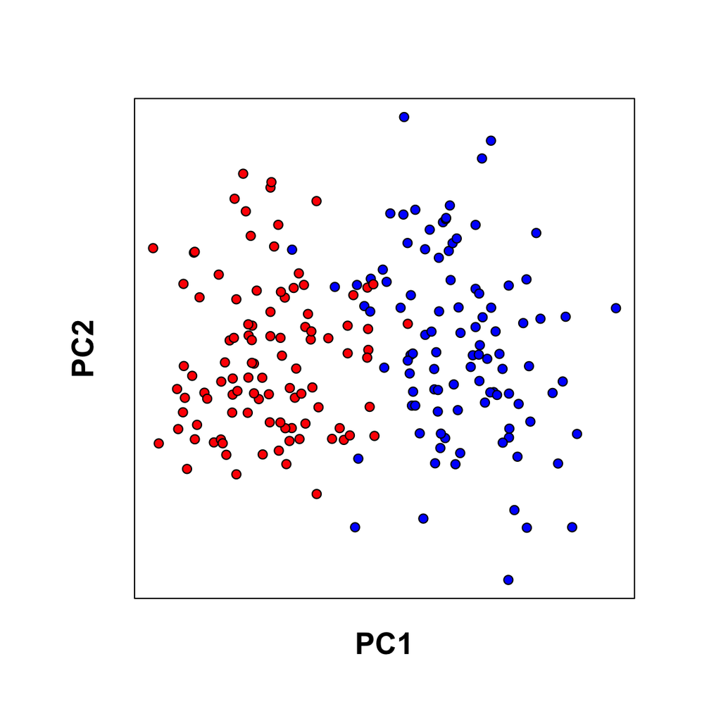

```r
par(pty="s", mgp=c(1.5,0,0), font.lab=2, cex.lab=1.5)
plot(snp.p[,1:2], pch=21, bg=rep(c("blue","red"),each=100), xaxt="n", yaxt="n", xlab="PC1", ylab="PC2")
```

Simulate a new set of 50 samples from the first population.

```r
n3 <- 50
z3 <- my.snp.pc.data(n3,maf1)
z3 <- data.frame(z3)
head(z3)
```

```
##   X1 X2 X3 X4 X5 X6 X7 X8 X9 X10 X11 X12 X13 X14 X15 X16 X17 X18 X19 X20 X21 X22 X23 X24 X25 X26 X27 X28 X29
## 1  0  1  0  0  1  1  2  0  0   0   1   0   0   1   1   1   0   0   0   1   2   0   1   0   0   0   0   0   0
## 2  1  1  2  2  1  1  2  0  0   0   0   0   1   1   1   0   1   2   2   0   2   0   0   0   1   0   0   0   2
## 3  0  0  2  0  0  0  1  0  0   0   1   1   1   0   1   1   1   1   1   1   1   1   1   0   0   1   0   1   1
## 4  1  0  1  1  1  0  1  0  0   1   0   0   0   0   0   1   1   1   0   0   1   0   1   0   0   0   0   0   1
## 5  1  0  1  1  0  2  0  0  1   0   0   1   2   1   1   0   1   0   0   0   1   1   0   1   1   0   0   0   2
## 6  0  1  0  1  0  2  0  1  1   0   1   0   1   1   1   1   0   1   1   2   1   0   2   0   0   1   0   1   0
##   X30 X31 X32 X33 X34 X35 X36 X37 X38 X39 X40 X41 X42 X43 X44 X45 X46 X47 X48 X49 X50
## 1   0   1   0   0   1   2   1   2   1   0   2   1   0   0   0   0   0   0   0   1   1
## 2   0   0   1   1   0   0   1   0   1   0   1   0   1   1   0   1   1   1   1   0   1
## 3   0   0   0   0   1   1   2   0   0   1   0   1   0   2   0   0   0   0   0   1   0
## 4   0   0   1   0   0   1   1   2   0   0   2   1   0   1   0   0   2   0   2   1   0
## 5   0   2   2   1   0   1   1   1   0   1   0   0   2   2   0   1   1   0   0   1   2
## 6   0   1   0   0   1   0   1   1   0   1   0   2   0   1   1   0   2   0   0   1   1
```

Add these 50 samples to the first two principal components plot.

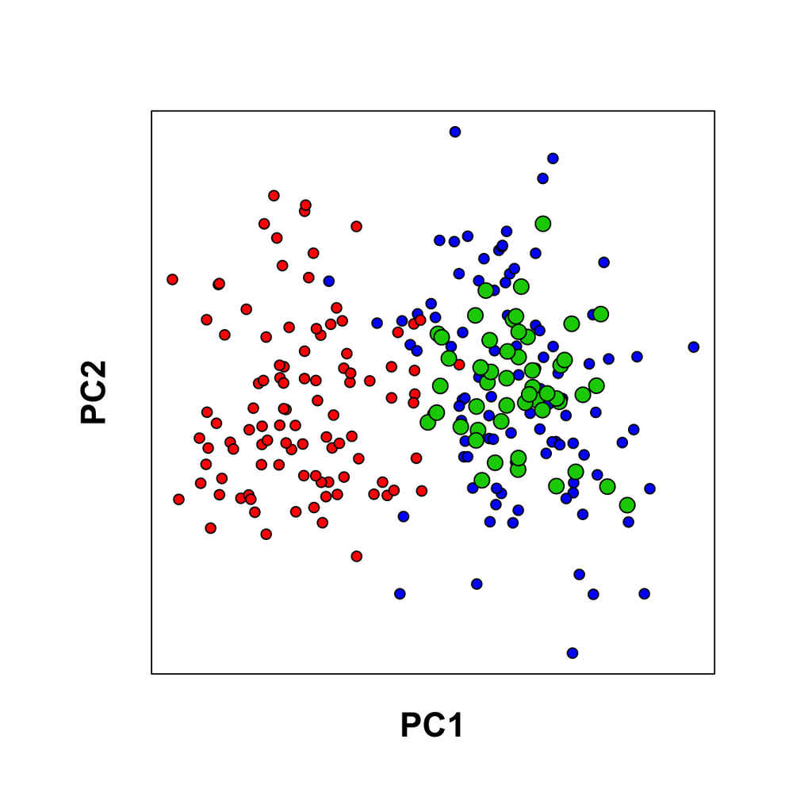

```r
p3 <- predict(snp.pca,z3)
par(pty="s", mgp=c(1.5,0,0), font.lab=2, cex.lab=1.5)
plot(snp.p[,1:2], pch=21, bg=rep(c("blue","red"),each=100), xaxt="n", yaxt="n", xlab="PC1", ylab="PC2")
points(p3[,1:2], pch=21, bg="green3", cex=1.5)
```